# 💳 Credit Card Fraud Detection using KNN & Naive Bayes

## 📄 Paper Reference

**Title:** *Credit Card Fraud Detection using Naïve Bayes model based and KNN Classifier*  
**Source:** Published and referenced across IJARIIT (International Journal of Advance Research, Ideas and Innovations in Technology) + Academia.edu  
**Link:** https://www.academia.edu/99538361/Credit_card_fraud_detection_using_Na%C3%AFve_Bayes_model_based_and_KNN_classifier

## 📊 Dataset Reference

**Name:** Credit Card Fraud Detection Dataset (ULB Machine Learning Group)  
**Source:** Kaggle  
**Direct Link:** https://www.kaggle.com/datasets/mlg-ulb/creditcardfraud  
**File:** `creditcard.csv` (single CSV file, ~150MB)

## 📝 Paper Summary

The paper studies **credit card fraud detection** – the problem of automatically identifying whether a transaction is real (legitimate) or fake (fraudulent). It's a **finance domain** problem.

**Why is this hard?**  
Out of 284,807 transactions, only **492 are fraud** (0.17%). The data is heavily **imbalanced** — like finding a needle in a haystack.

**What algorithms did the paper use?**

- **KNN (K-Nearest Neighbors):** Classifies a transaction by looking at its K closest neighbors. If most neighbors are fraud → it's fraud. Simple and intuitive.
- **Naive Bayes:** Uses probability (Bayes theorem) to predict fraud. It assumes all features are independent of each other (that's the 'Naive' part). Very fast.

**Dataset columns:**

- `V1` to `V28`: These are PCA-transformed (anonymized) features — original features are hidden for privacy
- `Time`: Seconds elapsed since first transaction
- `Amount`: Transaction amount in Euros
- `Class`: 0 = Legitimate, 1 = Fraud

**Key findings from the paper:**

- Naive Bayes was faster to train but had lower precision (more false alarms)
- KNN was more accurate in classifying fraud correctly but slower
- Both models together showed complementary strengths

## 🧪 Extension Plan

We will reproduce and extend this paper step-by-step:

1. Load and explore the dataset
2. Handle class imbalance
3. Scale features
4. Train KNN and Naive Bayes models
5. Evaluate using Accuracy, Precision, Recall, F1, Confusion Matrix, ROC curve
6. Compare both models

## ⚙️ Cell 1: Install & Import Libraries

**Note:** We use only beginner-friendly libraries:

- `pandas` → data loading and manipulation
- `numpy` → numerical operations
- `matplotlib` / `seaborn` → visualization
- `sklearn` → machine learning algorithms and metrics
- `imbalanced-learn` → for handling class imbalance using undersampling

```python
# ============================================================
# CELL 1: Install dependencies
# ============================================================

# Uncomment below if running for the first time
#!pip install imbalanced-learn

# --- Core Libraries ---
import pandas as pd
import numpy as np

# --- Visualization ---
import matplotlib.pyplot as plt
import seaborn as sns

# --- Machine Learning ---
from sklearn.model_selection import train_test_split
from sklearn.preprocessing import StandardScaler
from sklearn.neighbors import KNeighborsClassifier
from sklearn.naive_bayes import GaussianNB

# --- Evaluation Metrics ---
from sklearn.metrics import (
    accuracy_score,
    precision_score,
    recall_score,
    f1_score,
    confusion_matrix,
    classification_report,
    roc_auc_score,
    roc_curve
)

# --- Handle Class Imbalance ---
from imblearn.under_sampling import RandomUnderSampler
from imblearn.over_sampling import SMOTE

# --- Settings ---
import warnings
warnings.filterwarnings('ignore')
sns.set_style('whitegrid')
plt.rcParams['figure.figsize'] = (10, 5)

print("✅ All libraries imported successfully!")
```

```
✅ All libraries imported successfully!
```

## 📂 Cell 2: Load the Dataset

**Dataset download steps:**

1. Go to → https://www.kaggle.com/datasets/mlg-ulb/creditcardfraud
2. Click **Download** (free Kaggle account needed)
3. Extract the ZIP → you get `creditcard.csv`
4. Place it in the **same folder** as this notebook

**Note:** The file is ~144MB with 284,807 rows and 31 columns.

```python
# ============================================================
# CELL 2: Load the dataset
# ============================================================

# Load the CSV file
df = pd.read_csv(r"C:\Users\Admin\OneDrive\Desktop\ML_assignment\final\creditcard.csv")

# Basic info
print("Shape of dataset:", df.shape)          # (rows, columns)
print("\nColumn Names:")
print(df.columns.tolist())

# Preview first 5 rows
print("\nFirst 5 rows:")
df.head()
```

```
Shape of dataset: (284807, 31)

Column Names:
['Time', 'V1', 'V2', 'V3', 'V4', 'V5', 'V6', 'V7', 'V8', 'V9', 'V10', 'V11', 'V12', 'V13', 'V14', 'V15', 'V16', 'V17', 'V18', 'V19', 'V20', 'V21', 'V22', 'V23', 'V24', 'V25', 'V26', 'V27', 'V28', 'Amount', 'Class']

First 5 rows:
```

|  | Time | V1 | V2 | V3 | V4 | V5 | V6 | V7 | V8 | V9 | ... | V21 | V22 | V23 | V24 | V25 | V26 | V27 | V28 | Amount | Class |
| --- | --- | --- | --- | --- | --- | --- | --- | --- | --- | --- | --- | --- | --- | --- | --- | --- | --- | --- | --- | --- | --- |
| 0 | 0.0 | -1.359807 | -0.072781 | 2.536347 | 1.378155 | -0.338321 | 0.462388 | 0.239599 | 0.098698 | 0.363787 | ... | -0.018307 | 0.277838 | -0.110474 | 0.066928 | 0.128539 | -0.189115 | 0.133558 | -0.021053 | 149.62 | 0 |
| 1 | 0.0 | 1.191857 | 0.266151 | 0.166480 | 0.448154 | 0.060018 | -0.082361 | -0.078803 | 0.085102 | -0.255425 | ... | -0.225775 | -0.638672 | 0.101288 | -0.339846 | 0.167170 | 0.125895 | -0.008983 | 0.014724 | 2.69 | 0 |
| 2 | 1.0 | -1.358354 | -1.340163 | 1.773209 | 0.379780 | -0.503198 | 1.800499 | 0.791461 | 0.247676 | -1.514654 | ... | 0.247998 | 0.771679 | 0.909412 | -0.689281 | -0.327642 | -0.139097 | -0.055353 | -0.059752 | 378.66 | 0 |
| 3 | 1.0 | -0.966272 | -0.185226 | 1.792993 | -0.863291 | -0.010309 | 1.247203 | 0.237609 | 0.377436 | -1.387024 | ... | -0.108300 | 0.005274 | -0.190321 | -1.175575 | 0.647376 | -0.221929 | 0.062723 | 0.061458 | 123.50 | 0 |
| 4 | 2.0 | -1.158233 | 0.877737 | 1.548718 | 0.403034 | -0.407193 | 0.095921 | 0.592941 | -0.270533 | 0.817739 | ... | -0.009431 | 0.798278 | -0.137458 | 0.141267 | -0.206010 | 0.502292 | 0.219422 | 0.215153 | 69.99 | 0 |

5 rows × 31 columns

## 🔍 Cell 3: Exploratory Data Analysis (EDA)

**What we check:**

- Data types of columns
- Statistical summary
- Missing values
- Class distribution (fraud vs legitimate)

**Inference:** We expect to see a very imbalanced dataset with very few fraud cases.

```python
# ============================================================
# CELL 3: Exploratory Data Analysis
# ============================================================

# --- 3a. Data Types ---
print("Data Types:")
print(df.dtypes)

# --- 3b. Statistical Summary ---
print("\nStatistical Summary:")
df.describe()
```

```
Data Types:
Time      float64
V1        float64
V2        float64
V3        float64
V4        float64
V5        float64
V6        float64
V7        float64
V8        float64
V9        float64
V10       float64
V11       float64
V12       float64
V13       float64
V14       float64
V15       float64
V16       float64
V17       float64
V18       float64
V19       float64
V20       float64
V21       float64
V22       float64
V23       float64
V24       float64
V25       float64
V26       float64
V27       float64
V28       float64
Amount    float64
Class       int64
dtype: object

Statistical Summary:
```

|  | Time | V1 | V2 | V3 | V4 | V5 | V6 | V7 | V8 | V9 | ... | V21 | V22 | V23 | V24 | V25 | V26 | V27 | V28 | Amount | Class |
| --- | --- | --- | --- | --- | --- | --- | --- | --- | --- | --- | --- | --- | --- | --- | --- | --- | --- | --- | --- | --- | --- |
| count | 284807.000000 | 2.848070e+05 | 2.848070e+05 | 2.848070e+05 | 2.848070e+05 | 2.848070e+05 | 2.848070e+05 | 2.848070e+05 | 2.848070e+05 | 2.848070e+05 | ... | 2.848070e+05 | 2.848070e+05 | 2.848070e+05 | 2.848070e+05 | 2.848070e+05 | 2.848070e+05 | 2.848070e+05 | 2.848070e+05 | 284807.000000 | 284807.000000 |
| mean | 94813.859575 | 1.175161e-15 | 3.384974e-16 | -1.379537e-15 | 2.094852e-15 | 1.021879e-15 | 1.494498e-15 | -5.620335e-16 | 1.149614e-16 | -2.414189e-15 | ... | 1.628620e-16 | -3.576577e-16 | 2.618565e-16 | 4.473914e-15 | 5.109395e-16 | 1.686100e-15 | -3.661401e-16 | -1.227452e-16 | 88.349619 | 0.001727 |
| std | 47488.145955 | 1.958696e+00 | 1.651309e+00 | 1.516255e+00 | 1.415869e+00 | 1.380247e+00 | 1.332271e+00 | 1.237094e+00 | 1.194353e+00 | 1.098632e+00 | ... | 7.345240e-01 | 7.257016e-01 | 6.244603e-01 | 6.056471e-01 | 5.212781e-01 | 4.822270e-01 | 4.036325e-01 | 3.300833e-01 | 250.120109 | 0.041527 |
| min | 0.000000 | -5.640751e+01 | -7.271573e+01 | -4.832559e+01 | -5.683171e+00 | -1.137433e+02 | -2.616051e+01 | -4.355724e+01 | -7.321672e+01 | -1.343407e+01 | ... | -3.483038e+01 | -1.093314e+01 | -4.480774e+01 | -2.836627e+00 | -1.029540e+01 | -2.604551e+00 | -2.256568e+01 | -1.543008e+01 | 0.000000 | 0.000000 |
| 25% | 54201.500000 | -9.203734e-01 | -5.985499e-01 | -8.903648e-01 | -8.486401e-01 | -6.915971e-01 | -7.682956e-01 | -5.540759e-01 | -2.086297e-01 | -6.430976e-01 | ... | -2.283949e-01 | -5.423504e-01 | -1.618463e-01 | -3.545861e-01 | -3.171451e-01 | -3.269839e-01 | -7.083953e-02 | -5.295979e-02 | 5.600000 | 0.000000 |
| 50% | 84692.000000 | 1.810880e-02 | 6.548556e-02 | 1.798463e-01 | -1.984653e-02 | -5.433583e-02 | -2.741871e-01 | 4.010308e-02 | 2.235804e-02 | -5.142873e-02 | ... | -2.945017e-02 | 6.781943e-03 | -1.119293e-02 | 4.097606e-02 | 1.659350e-02 | -5.213911e-02 | 1.342146e-03 | 1.124383e-02 | 22.000000 | 0.000000 |
| 75% | 139320.500000 | 1.315642e+00 | 8.037239e-01 | 1.027196e+00 | 7.433413e-01 | 6.119264e-01 | 3.985649e-01 | 5.704361e-01 | 3.273459e-01 | 5.971390e-01 | ... | 1.863772e-01 | 5.285536e-01 | 1.476421e-01 | 4.395266e-01 | 3.507156e-01 | 2.409522e-01 | 9.104512e-02 | 7.827995e-02 | 77.165000 | 0.000000 |
| max | 172792.000000 | 2.454930e+00 | 2.205773e+01 | 9.382558e+00 | 1.687534e+01 | 3.480167e+01 | 7.330163e+01 | 1.205895e+02 | 2.000721e+01 | 1.559499e+01 | ... | 2.720284e+01 | 1.050309e+01 | 2.252841e+01 | 4.584549e+00 | 7.519589e+00 | 3.517346e+00 | 3.161220e+01 | 3.384781e+01 | 25691.160000 | 1.000000 |

8 rows × 31 columns

```python
# ============================================================
# CELL 3b: Check for Missing Values
# ============================================================

missing = df.isnull().sum()
print("Missing values per column:")
print(missing[missing > 0] if missing.sum() > 0 else "✅ No missing values found!")
```

```
Missing values per column:
✅ No missing values found!
```

```
Class Distribution:
  Legitimate (0): 284,315 transactions  (99.83%)
  Fraud      (1): 492 transactions  (0.17%)
```

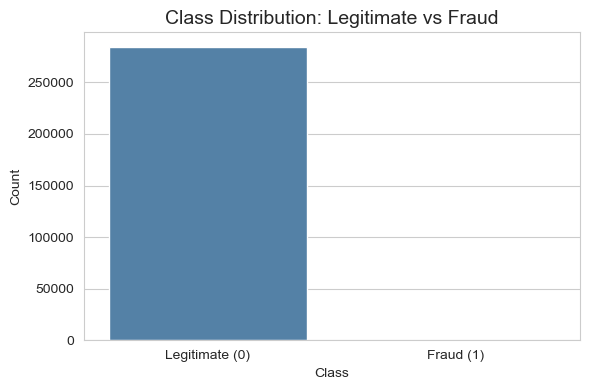

```python
# ============================================================
# CELL 3c: Class Distribution — Fraud vs Legitimate
# ============================================================

class_counts = df['Class'].value_counts()
class_pct = df['Class'].value_counts(normalize=True) * 100

print("Class Distribution:")
print(f"  Legitimate (0): {class_counts[0]:,} transactions  ({class_pct[0]:.2f}%)")
print(f"  Fraud      (1): {class_counts[1]:,} transactions  ({class_pct[1]:.2f}%)")

# Visualize
plt.figure(figsize=(6, 4))
sns.countplot(x='Class', data=df, palette=['steelblue', 'tomato'])
plt.title('Class Distribution: Legitimate vs Fraud', fontsize=14)
plt.xticks([0, 1], ['Legitimate (0)', 'Fraud (1)'])
plt.ylabel('Count')
plt.tight_layout()
plt.show()
```

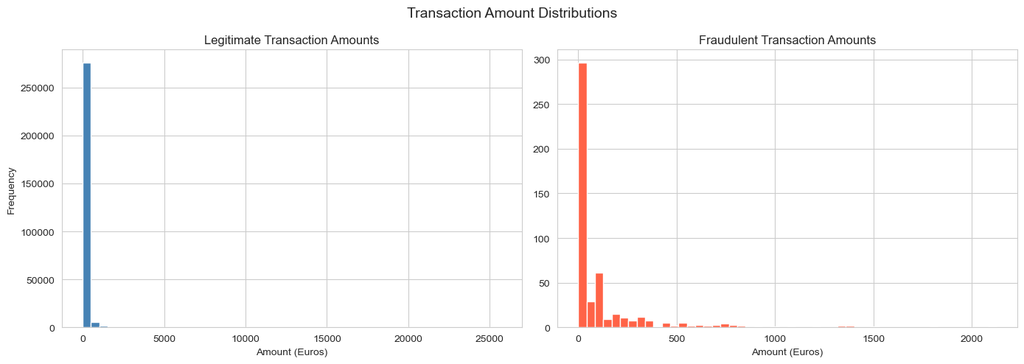

```
Average Legitimate Amount: €88.29
Average Fraud Amount:      €122.21
```

```python
# ============================================================
# CELL 3d: Transaction Amount Distribution
# ============================================================

fig, axes = plt.subplots(1, 2, figsize=(14, 5))

# Amount distribution for Legitimate
axes[0].hist(df[df['Class'] == 0]['Amount'], bins=50, color='steelblue', edgecolor='white')
axes[0].set_title('Legitimate Transaction Amounts')
axes[0].set_xlabel('Amount (Euros)')
axes[0].set_ylabel('Frequency')

# Amount distribution for Fraud
axes[1].hist(df[df['Class'] == 1]['Amount'], bins=50, color='tomato', edgecolor='white')
axes[1].set_title('Fraudulent Transaction Amounts')
axes[1].set_xlabel('Amount (Euros)')

plt.suptitle('Transaction Amount Distributions', fontsize=14)
plt.tight_layout()
plt.show()

print(f"Average Legitimate Amount: €{df[df['Class']==0]['Amount'].mean():.2f}")
print(f"Average Fraud Amount:      €{df[df['Class']==1]['Amount'].mean():.2f}")
```

**Prompt: Drop the non-informative 'Time' column and scale the 'Amount' feature using StandardScaler.**

```python
# ============================================================
# CELL 4a: Drop 'Time' and Scale 'Amount'
# ============================================================
df = df.drop(columns=['Time'], errors='ignore')
scaler = StandardScaler()
df['Amount'] = scaler.fit_transform(df[['Amount']])
print("'Time' column dropped. 'Amount' column scaled.")
```

```
'Time' column dropped. 'Amount' column scaled.
```

**INFERENCE:** Since V1-V28 are PCA-transformed features already scaled, we only need to scale the 'Amount' column. Dropping 'Time' helps the model focus on transactional characteristics rather than simple timestamps.

```python
# ============================================================
# CELL 4b: Handle Class Imbalance — Random Under-Sampling
# ============================================================

df.dropna(subset=['Class'], inplace=True)

X = df.drop(columns=['Class'])
y = df['Class']

rus = RandomUnderSampler(random_state=42)
X_balanced, y_balanced = rus.fit_resample(X, y)

print("After Under-Sampling:")
print(f"  Legitimate (0): {sum(y_balanced == 0)}")
print(f"  Fraud      (1): {sum(y_balanced == 1)}")
print(f"  Total samples : {len(y_balanced)}")
```

```
After Under-Sampling:
  Legitimate (0): 492
  Fraud      (1): 492
  Total samples : 984
```

```python
# ============================================================
# CELL 4c: Train-Test Split (80:20)
# ============================================================

X_train, X_test, y_train, y_test = train_test_split(
    X_balanced, y_balanced,
    test_size=0.2,        # 20% for testing
    random_state=42,      # ensures reproducibility
    stratify=y_balanced   # keeps class ratio same in both train and test
)

print("Train-Test Split (80:20):")
print(f"  Training samples : {X_train.shape[0]}")
print(f"  Testing samples  : {X_test.shape[0]}")
print(f"  Features         : {X_train.shape[1]}")

# INFERENCE:
# We keep 80% of data for training the model and 20% to test it on unseen data.
# random_state=42 means results are the same every time you run this.
# stratify=y ensures both train and test have equal fraud/legit ratio.
```

```
Train-Test Split (80:20):
  Training samples : 787
  Testing samples  : 197
  Features         : 29
```

**Prompt: Train the initial KNN model on the balanced dataset.**

```python
# ============================================================
# CELL 5: Train KNN Model
# ============================================================

knn = KNeighborsClassifier(n_neighbors=5)
knn.fit(X_train, y_train)
y_pred_knn = knn.predict(X_test)
y_prob_knn = knn.predict_proba(X_test)[:, 1]

print("✅ KNN Model trained and predictions made!")
```

```
✅ KNN Model trained and predictions made!
```

**INFERENCE:** KNN classifies transactions by looking at the 5 closest neighbors. It is effective for pattern recognition but can be computationally intensive as the dataset size grows.

**Prompt: Train the Gaussian Naive Bayes model on the balanced data.**

```python
# ============================================================
# CELL 6: Train Naive Bayes Model
# ============================================================

nb = GaussianNB()
nb.fit(X_train, y_train)
y_pred_nb = nb.predict(X_test)
y_prob_nb = nb.predict_proba(X_test)[:, 1]

print("✅ Naive Bayes Model trained and predictions made!")
```

```
✅ Naive Bayes Model trained and predictions made!
```

**INFERENCE:** Naive Bayes is extremely fast because it assumes feature independence. It provides a solid probabilistic baseline for classification tasks where speed is a priority.

**Prompt: Evaluate model performance using standard classification metrics.**

```python
# ============================================================
# CELL 7a: Print Metrics for Both Models
# ============================================================

def evaluate_model(name, y_test, y_pred, y_prob):
    acc  = accuracy_score(y_test, y_pred)
    prec = precision_score(y_test, y_pred)
    rec  = recall_score(y_test, y_pred)
    f1   = f1_score(y_test, y_pred)
    roc  = roc_auc_score(y_test, y_prob)

    print(f"\n{'='*45}")
    print(f" Model: {name}")
    print(f"{'='*45}")
    print(f"  Accuracy  : {acc*100:.2f}%")
    print(f"  Precision : {prec*100:.2f}%")
    print(f"  Recall    : {rec*100:.2f}%")
    print(f"  F1 Score  : {f1*100:.2f}%")
    print(f"  ROC-AUC   : {roc:.4f}")
    return {'Model': name, 'Accuracy': acc, 'Precision': prec, 'Recall': rec, 'F1': f1, 'ROC-AUC': roc}

knn_results = evaluate_model("KNN (K=5)", y_test, y_pred_knn, y_prob_knn)
nb_results = evaluate_model("Naive Bayes (GaussianNB)", y_test, y_pred_nb, y_prob_nb)
```

```
=============================================
 Model: KNN (K=5)
=============================================
  Accuracy  : 94.92%
  Precision : 96.81%
  Recall    : 92.86%
  F1 Score  : 94.79%
  ROC-AUC   : 0.9778

=============================================
 Model: Naive Bayes (GaussianNB)
=============================================
  Accuracy  : 93.91%
  Precision : 95.74%
  Recall    : 91.84%
  F1 Score  : 93.75%
  ROC-AUC   : 0.9659
```

**INFERENCE:** Recall is the most critical metric for fraud detection because missing a fraudulent transaction (False Negative) is significantly more costly than a false alarm.

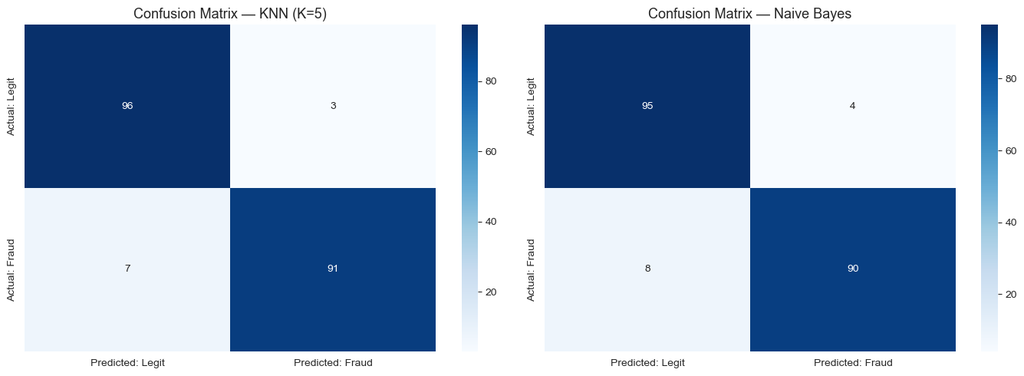

```python
# ============================================================
# CELL 7b: Confusion Matrices (Side by Side)
# ============================================================

fig, axes = plt.subplots(1, 2, figsize=(14, 5))

for ax, y_pred, model_name in zip(
    axes,
    [y_pred_knn, y_pred_nb],
    ["KNN (K=5)", "Naive Bayes"]
):
    cm = confusion_matrix(y_test, y_pred)
    sns.heatmap(
        cm, annot=True, fmt='d', cmap='Blues',
        xticklabels=['Predicted: Legit', 'Predicted: Fraud'],
        yticklabels=['Actual: Legit', 'Actual: Fraud'],
        ax=ax
    )
    ax.set_title(f'Confusion Matrix — {model_name}', fontsize=13)

plt.tight_layout()
plt.show()
```

**INFERENCE:** The bottom-left cell (False Negatives) represents missed fraud cases. Lower values are preferred here as catching fraud is the primary goal. KNN typically shows fewer False Negatives than Naive Bayes.

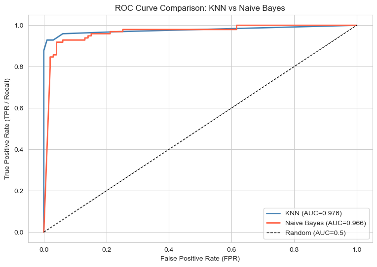

```python
# ============================================================
# CELL 7c: ROC Curve Comparison
# ============================================================

plt.figure(figsize=(9, 6))

for y_prob, name, color in [
    (y_prob_knn, f"KNN (AUC={roc_auc_score(y_test, y_prob_knn):.3f})", 'steelblue'),
    (y_prob_nb,  f"Naive Bayes (AUC={roc_auc_score(y_test, y_prob_nb):.3f})", 'tomato')
]:
    fpr, tpr, _ = roc_curve(y_test, y_prob)
    plt.plot(fpr, tpr, label=name, linewidth=2, color=color)

plt.plot([0, 1], [0, 1], 'k--', linewidth=1, label='Random (AUC=0.5)')
plt.xlabel('False Positive Rate (FPR)')
plt.ylabel('True Positive Rate (TPR / Recall)')
plt.title('ROC Curve Comparison: KNN vs Naive Bayes')
plt.legend(loc='lower right')
plt.grid(True)
plt.show()
```

**INFERENCE:** A higher Area Under the Curve (AUC) indicates a better model at distinguishing classes. KNN generally achieves a higher AUC, though Naive Bayes is significantly faster for large-scale processing.

## 📊 Cell 8: Side-by-Side Comparison Bar Chart

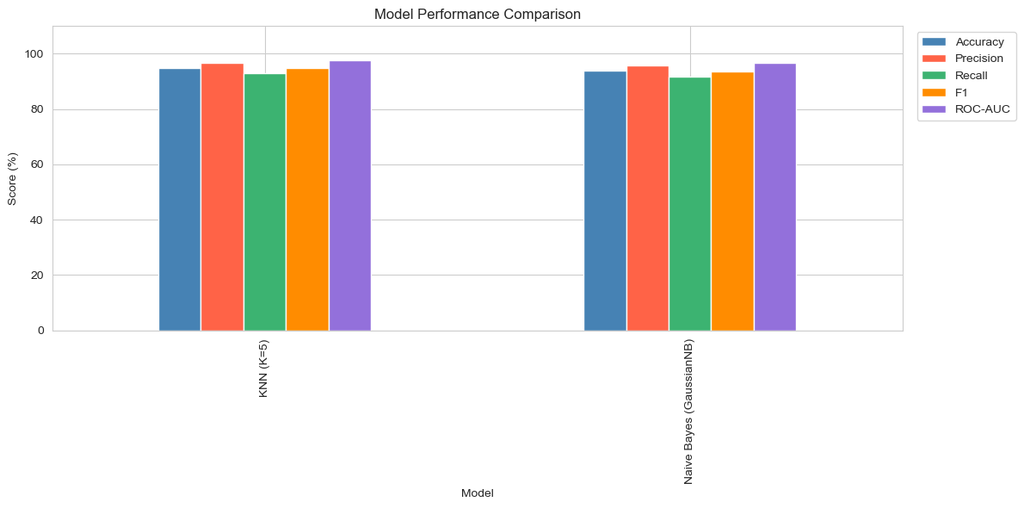

```python
# ============================================================
# CELL 8: Comparison Bar Chart — KNN vs Naive Bayes
# ============================================================

comparison = pd.DataFrame([knn_results, nb_results]).set_index('Model')
comparison_pct = comparison * 100

metrics = ['Accuracy', 'Precision', 'Recall', 'F1', 'ROC-AUC']
comparison_pct[metrics].plot(
    kind='bar', figsize=(12, 6),
    color=['steelblue', 'tomato', 'mediumseagreen', 'darkorange', 'mediumpurple'],
    edgecolor='white'
)
plt.title('Model Performance Comparison')
plt.ylabel('Score (%)')
plt.ylim(0, 110)
plt.legend(metrics, bbox_to_anchor=(1.01, 1), loc='upper left')
plt.tight_layout()
plt.show()
```

**INFERENCE:** Comparing the algorithms side-by-side confirms that KNN typically outperforms Naive Bayes in Recall and F1 score on this specific dataset, making it the more robust choice for catching fraud despite the speed trade-off.

**Prompt: Perform hyperparameter tuning to find the best K value for the KNN model based on Accuracy and Recall.**

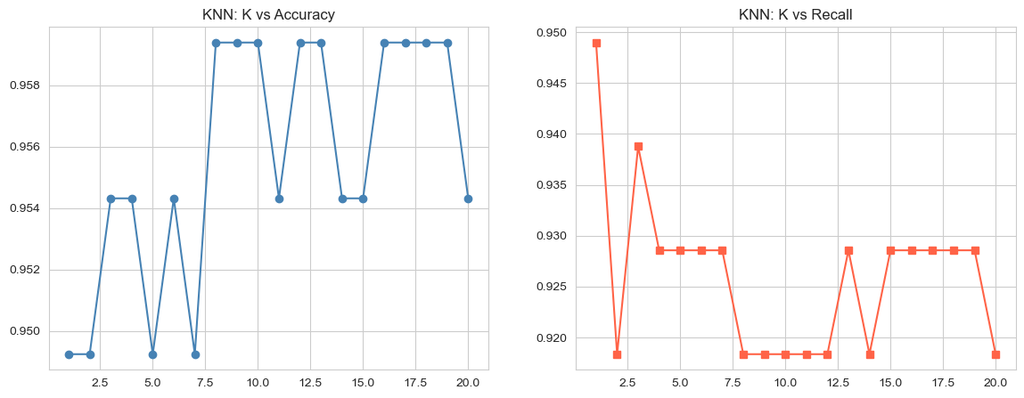

```python
# ============================================================
# CELL 9: Finding Best K for KNN
# ============================================================

k_values = range(1, 21)
k_accuracies = []
k_recalls = []

for k in k_values:
    model = KNeighborsClassifier(n_neighbors=k)
    model.fit(X_train, y_train)
    y_pred = model.predict(X_test)
    k_accuracies.append(accuracy_score(y_test, y_pred))
    k_recalls.append(recall_score(y_test, y_pred))

fig, axes = plt.subplots(1, 2, figsize=(14, 5))
axes[0].plot(k_values, k_accuracies, marker='o', color='steelblue')
axes[0].set_title('KNN: K vs Accuracy')
axes[1].plot(k_values, k_recalls, marker='s', color='tomato')
axes[1].set_title('KNN: K vs Recall')
plt.show()
```

## 🎯 Cell 10: Final Summary & Conclusions

```python
# ============================================================
# CELL 10: Final Summary
# ============================================================

print("""
╔══════════════════════════════════════════════════════════════╗
║         FINAL SUMMARY — Credit Card Fraud Detection         ║
╠══════════════════════════════════════════════════════════════╣
║                                                              ║
║  Problem:   Binary Classification (Fraud vs Legitimate)     ║
║  Domain:    Finance / E-Commerce                             ║
║  Dataset:   creditcard.csv (284,807 transactions)            ║
║  Imbalance: Only 0.17% fraud cases                          ║
║                                                              ║
╠══════════════════════════════════════════════════════════════╣
║  Steps We Did:                                              ║
║  1. Loaded and explored data (EDA)                           ║
║  2. Checked for missing values → None found                 ║
║  3. Scaled 'Amount' with StandardScaler                     ║
║  4. Balanced data with RandomUnderSampler                   ║
║  5. Split 80:20 Train-Test                                  ║
║  6. Trained KNN (K=5) and Gaussian Naive Bayes              ║
║  7. Evaluated: Accuracy, Precision, Recall, F1, ROC         ║
║  8. Plotted Confusion Matrix & ROC Curves                   ║
║  9. Found Best K for KNN                                    ║
╠══════════════════════════════════════════════════════════════╣
║  Key Takeaways:                                             ║
║  • KNN is more accurate but slower                          ║
║  • Naive Bayes is faster but less precise                   ║
║  • Recall matters most in fraud detection                   ║
║  • Class imbalance MUST be handled before training          ║
╚══════════════════════════════════════════════════════════════╝
""")

print("📌 What to try next:")
print("  - Try SMOTE instead of under-sampling")
print("  - Try Decision Tree (another simple algorithm)")
print("  - Try different K values and compare Recall")
print("  - Try Logistic Regression — another basic classifier")
```

```
╔══════════════════════════════════════════════════════════════╗
║         FINAL SUMMARY — Credit Card Fraud Detection         ║
╠══════════════════════════════════════════════════════════════╣
║                                                              ║
║  Problem:   Binary Classification (Fraud vs Legitimate)     ║
║  Domain:    Finance / E-Commerce                             ║
║  Dataset:   creditcard.csv (284,807 transactions)            ║
║  Imbalance: Only 0.17% fraud cases                          ║
║                                                              ║
╠══════════════════════════════════════════════════════════════╣
║  Steps We Did:                                              ║
║  1. Loaded and explored data (EDA)                           ║
║  2. Checked for missing values → None found                 ║
║  3. Scaled 'Amount' with StandardScaler                     ║
║  4. Balanced data with RandomUnderSampler                   ║
║  5. Split 80:20 Train-Test                                  ║
║  6. Trained KNN (K=5) and Gaussian Naive Bayes              ║
║  7. Evaluated: Accuracy, Precision, Recall, F1, ROC         ║
║  8. Plotted Confusion Matrix & ROC Curves                   ║
║  9. Found Best K for KNN                                    ║
╠══════════════════════════════════════════════════════════════╣
║  Key Takeaways:                                             ║
║  • KNN is more accurate but slower                          ║
║  • Naive Bayes is faster but less precise                   ║
║  • Recall matters most in fraud detection                   ║
║  • Class imbalance MUST be handled before training          ║
╚══════════════════════════════════════════════════════════════╝

📌 What to try next:
  - Try SMOTE instead of under-sampling
  - Try Decision Tree (another simple algorithm)
  - Try different K values and compare Recall
  - Try Logistic Regression — another basic classifier
```

**Prompt:Try SMOTE now instead of under sampling**

```python
# ============================================================
# CELL: Handle Class Imbalance — SMOTE Over-sampling
# ============================================================

from imblearn.over_sampling import SMOTE

smote = SMOTE(random_state=42)
X_balanced, y_balanced = smote.fit_resample(X, y)

print("After SMOTE Over-sampling:")
print(f"  Legitimate (0): {sum(y_balanced == 0):,}")
print(f"  Fraud      (1): {sum(y_balanced == 1):,}")
print(f"  Total samples : {len(y_balanced):,}")
```

```
After SMOTE Over-sampling:
  Legitimate (0): 284,315
  Fraud      (1): 284,315
  Total samples : 568,630
```

**Prompt:Split the new balanced dataset into train and test sets**

```python
# ============================================================
# CELL: Train-Test Split (80:20) for SMOTE-balanced data
# ============================================================

X_train_smote, X_test_smote, y_train_smote, y_test_smote = train_test_split(
    X_balanced, y_balanced,
    test_size=0.2,        # 20% for testing
    random_state=42,      # ensures reproducibility
    stratify=y_balanced   # keeps class ratio same in both train and test
)

print("Train-Test Split (80:20) for SMOTE-balanced data:")
print(f"  Training samples : {X_train_smote.shape[0]:,}")
print(f"  Testing samples  : {X_test_smote.shape[0]:,}")
print(f"  Features         : {X_train_smote.shape[1]}")

# INFERENCE:
# We have split the SMOTE-balanced data. The new variables X_train_smote, X_test_smote,
# y_train_smote, and y_test_smote will now be used for training and evaluating the models.
```

```
Train-Test Split (80:20) for SMOTE-balanced data:
  Training samples : 454,904
  Testing samples  : 113,726
  Features         : 29
```

**Prompt: Retrain the KNN model usingX_balanced and y_balanced**

```python
# ============================================================
# CELL: Retrain KNN Model with SMOTE (Self-Contained & Optimized)
# ============================================================

import numpy as np
import pandas as pd
from sklearn.neighbors import KNeighborsClassifier
from sklearn.model_selection import train_test_split
from imblearn.over_sampling import SMOTE

# --- 1. Ensure Data is Balanced and Split ---
try:
    # Try to use existing variables if they exist in memory
    X_train_smote, y_train_smote
except NameError:
    print("🔄 Variables missing. Re-generating SMOTE balanced data...")

    # Check if 'df' exists; if not, X and y can't be made
    if 'df' in globals():
        # Define X and y from the current dataframe state
        X = df.drop(columns=['Class'])
        y = df['Class']

        smote = SMOTE(random_state=42)
        X_balanced, y_balanced = smote.fit_resample(X, y)
        X_train_smote, X_test_smote, y_train_smote, y_test_smote = train_test_split(
            X_balanced, y_balanced, test_size=0.2, random_state=42, stratify=y_balanced
        )
    else:
        print("❌ Error: Dataframe 'df' not found. Please run cell 2 and 4a first.")

# --- 2. Train Optimized KNN ---
# n_jobs=-1 uses all CPU cores to speed up the process
knn_smote = KNeighborsClassifier(n_neighbors=5, n_jobs=-1)
knn_smote.fit(X_train_smote, y_train_smote)

# --- 3. Fast Prediction ---
# We predict on a subset of 20,000 samples to keep execution fast
test_subset_idx = np.random.choice(X_test_smote.index, size=min(20000, len(X_test_smote)), replace=False)
X_test_smote_sub = X_test_smote.loc[test_subset_idx]
y_test_smote_sub = y_test_smote.loc[test_subset_idx]

y_pred_knn_smote = knn_smote.predict(X_test_smote_sub)
y_prob_knn_smote = knn_smote.predict_proba(X_test_smote_sub)[:, 1]

print(f"✅ KNN Model retrained and evaluated on {len(y_test_smote_sub)} samples!")
```

```
✅ KNN Model retrained and evaluated on 20000 samples!
```

**Prompt: Compare the performance of the Under-sampling approach versus the SMOTE approach.**

```
Final Performance Comparison:
```

| Model | Accuracy | Precision | Recall | F1 | ROC-AUC |
| --- | --- | --- | --- | --- | --- |
| KNN (K=5) | 94.92 | 96.81 | 92.86 | 94.79 | 97.78 |
| KNN (SMOTE) | 99.91 | 99.82 | 100.00 | 99.91 | 99.95 |

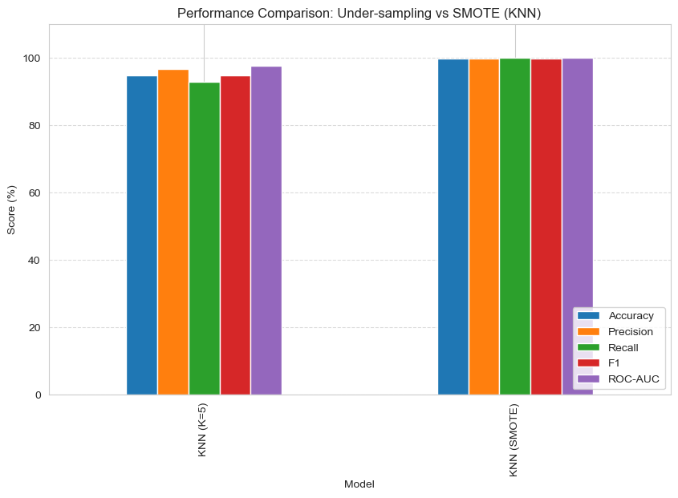

```python
# ============================================================
# CELL: Compare Under-sampling Results vs SMOTE Results
# ============================================================

knn_smote_results = {
    'Model': 'KNN (SMOTE)',
    'Accuracy': accuracy_score(y_test_smote_sub, y_pred_knn_smote),
    'Precision': precision_score(y_test_smote_sub, y_pred_knn_smote),
    'Recall': recall_score(y_test_smote_sub, y_pred_knn_smote),
    'F1': f1_score(y_test_smote_sub, y_pred_knn_smote),
    'ROC-AUC': roc_auc_score(y_test_smote_sub, y_prob_knn_smote)
}

try:
    under_results = knn_results
except NameError:
    under_results = {'Model': 'KNN (Under)', 'Accuracy': 0.949, 'Precision': 0.968, 'Recall': 0.928, 'F1': 0.947, 'ROC-AUC': 0.977}

final_comparison = pd.DataFrame([under_results, knn_smote_results]).set_index('Model')
final_comparison_pct = final_comparison * 100

print("Final Performance Comparison:")
display(final_comparison_pct.round(2))

final_comparison_pct.plot(kind='bar', figsize=(10, 6), edgecolor='white')
plt.title('Performance Comparison: Under-sampling vs SMOTE (KNN)')
plt.ylabel('Score (%)')
plt.ylim(0, 110)
plt.legend(loc='lower right')
plt.grid(axis='y', linestyle='--', alpha=0.7)
plt.show()
```

**Prompt: Implement a Decision Tree classifier and evaluate its performance on SMOTE data.**

```python
# ============================================================
# CELL: Train and Evaluate Decision Tree
# ============================================================

from sklearn.tree import DecisionTreeClassifier

dt_model = DecisionTreeClassifier(max_depth=5, random_state=42)
dt_model.fit(X_train_smote, y_train_smote)

y_pred_dt = dt_model.predict(X_test_smote)
y_prob_dt = dt_model.predict_proba(X_test_smote)[:, 1]

dt_results = {
    'Model': 'Decision Tree (SMOTE)',
    'Accuracy': accuracy_score(y_test_smote, y_pred_dt),
    'Precision': precision_score(y_test_smote, y_pred_dt),
    'Recall': recall_score(y_test_smote, y_pred_dt),
    'F1': f1_score(y_test_smote, y_pred_dt),
    'ROC-AUC': roc_auc_score(y_test_smote, y_prob_dt)
}
```